# R Notebook

- 4M4 A sample of students is measured for height each year for 3 years. After the third year, you want to fit a linear regression predicting height using year as a predictor. Write down the mathematical model definition for this regression, using any variable names and priors you choose. Be prepared to defend your choice of priors.

```r
model <- map(
  alist(
    height ~ dnorm(mean = mu, sd = sigma),
    mu <- alpha + beta*year,
    alpha ~ dnorm(mean = 170, sd = 100),
    sigma ~ dunif(min = 0, max = 50),
    beta ~ dnorm(mean = 0, sd = 10)
  ),
  data = d
)
```

- 4M5 Now suppose I tell you that the average height in the first year was 120 cm and that every student got taller each year. Does this information lead you to change your choice of priors? How?

Можно 1. сместить к 120 см и сделать так, чтобы beta было больше 0.

- 4M6 Now suppose I tell you that the variance among heights for students of the same age is never more than 64cm. How does this lead you to revise your priors?

Нужно выбрать распределение sigma которое будет обрываться на отметке 64 см.

- 4H3 Suppose a colleague of yours, who works on allometry, glances at the practice problems just above. Your colleague exclaims, “That’s silly. Everyone knows that it’s only the logarithm of body weight that scales with height!” Let’s take your colleague’s advice and see what happens.

** a Model the relationship between height (cm) and the natural logarithm of weight (log-kg). Use the entire Howell1 data frame, all 544 rows, adults and non-adults. Fit this model, using quadratic approximation: h i ∼ Normal(μ i , σ) μ i = α + β log(w i ) α ∼ Normal(178, 100) β ∼ Normal(0, 100) σ ∼ Uniform(0, 50) where h i is the height of individual i and w i is the weight (in kg) of individual i. The function for computing a natural log in R is just log . Can you interpret the resulting estimates?

```r
library(rethinking)
data(Howell1)
d <- Howell1
model <- map(
  alist(
    height ~ dnorm(mean = mu, sd = sigma),
    mu <- alpha + beta*log(weight),
    alpha ~ dnorm(mean = 178, sd = 100),
    beta ~ dnorm(mean = 0, sd = 100),
    sigma ~ dunif(min = 0, max = 50)
  ),
  data = d
)
precis(model)
```

|  | Mean | StdDev | 5.5% | 94.5% |
| --- | --- | --- | --- | --- |
| alpha | -23.78 | 1.34 | -25.92 | -21.65 |
| beta | 47.08 | 0.38 | 46.46 | 47.69 |
| sigma | 5.13 | 0.16 | 4.89 | 5.38 |

** b Begin with this plot:

```
plot( height ~ weight , data=Howell1 ,
col=col.alpha(rangi2,0.4) )
```

Then use samples from the quadratic approximate posterior of the model in (a) to superimpose on the plot: (1) the predicted mean height as a function of weight, (2) the 97% HPDI for the mean, and (3) the 97% HPDI for predicted heights.

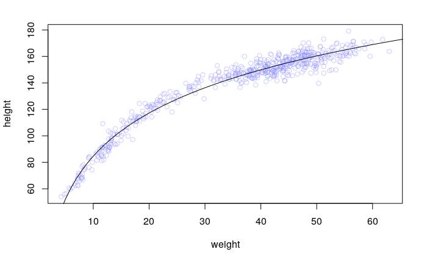

```r
library(MASS)
weight.seq <- seq(from = 1, to = 100, length.out = 100)
samples <- data.frame( mvrnorm(n = 1000, mu = coef(model), Sigma = vcov(model)) )
mu.link <- function(weight) samples$alpha + samples$beta * log(weight)
mu <- sapply(X = weight.seq, FUN = mu.link)
mu.mean <- apply(X = mu, MARGIN = 2, FUN = mean)
plot( height ~ weight, data=Howell1, col=col.alpha(rangi2,0.4) )
lines(x = weight.seq, y = mu.mean)
```